# Who We Are

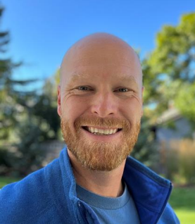

**Brendan Connors** - I am a Research Scientist based out of the Institute of Ocean Sciences in Victoria. I am an applied population ecologist by training, and fisheries scientist by experience. I originally joined DFO in 2018 as the Program Head for Sablefish (aka Black Cod), a long lived demersal species that supports a commercially important fishery off of Canada’s west coast. In 2021 I switched gears to start up a salmon focused research program with an emphasis on quantitative methods, salmon-ecosystem interactions, and fisheries risk assessment and management. Prior to joining DFO I did a postdoc in the [School of Resource and Environmental Management](https://www.sfu.ca/rem.html) at Simon Fraser University on salmon macroecology and assessment of indicators of conservation status, and then spent five years at [ESSA Technologies](http://essa.com). I completed my PhD at Simon Fraser University in the [Department of Biological Sciences](http://www.sfu.ca/biology.html) on parasite ecology and population level consequences of farmed and wild salmon interaction and spent most of my springs working out of the [Salmon Coast Field Station](https://salmoncoast.org/) in the Broughton Archipelago. A list of my publications is available in [Google Scholar](https://scholar.google.ca/citations?hl=en&user=bJAFbHQAAAAJ&view_op=list_works&sortby=pubdate).

**Cameron Freshwater** - I am a Research Scientist at the Pacific Biological Station in Nanaimo. I began researching salmon marine ecology as a PhD student at the University of Victoria and joined DFO as a postdoc in 2017 with Carrie Holt where I helped develop closed-loop simulation tools to support fisheries management. Since 2020 I have led the Applied Salmon Ecology Program which specializes in leveraging data from at-sea surveys and telemetry studies to parameterize life cycle models for ecosystem-based management. Our current projects are focused on marine spatial distributions, predator-prey interactions, and fishery impacts. A list of my publications are available on [Google Scholar](https://scholar.google.com/citations?user=UysZ3QcAAAAJ&hl=en).

**Carrie Holt** - I am a Research Scientist at the Pacific Biological Station with Fisheries and Oceans Canada in Nanaimo, BC, leading a program on assessment methods and decision support tools for Pacific salmon. This program aims to facilitate communication and decision-making at the interface between science and management. Research focuses on the development of reference points for Pacific salmon, decision-support tools that integrate harvest, hatchery and habitat impacts for salmon, and assessment approaches that interface western science and Indigenous Knowledge Systems. I started my research career as a young adventurer exploring and enjoying the lakes of Southern Ontario. I studied zooplankton in acid-damaged lakes in eastern Canada for my MSc, followed by a PhD in salmon assessment and management at Simon Fraser University, and post-doctoral research at the University of Washington incorporating climate variables into groundfish assessments. While trained in western science I aim to practice this discipline with openness to a plurality of knowledge systems. My publications are available on [Google Scholar](https://scholar.google.com/citations?user=ikV64uYAAAAJ&hl=en).

**Paul Van-Dam Bates** - I am a Research Scientist at the Pacific Biological station, working on estimating species composition of salmon on the Fraser River based on hydroacoustic data. I am an ecological statistician and am new to fisheries modelling. I am very interested in computational problems and contribute to the R package NIMBLE, developing numerical methods to approximate posterior distributions as well as efficient MCMC algorithms. I did my PhD at St Andrews in Scotland (2023), developing models to estimate animal density from camera traps and acoustics animal identities are not known. Before that, I worked as a government statistician at the Department of Conservation in New Zealand, developing national biodiversity monitoring programs. I completed my bachelors (2011) and masters degree (2014) at the University of Victoria, with a focus on capture-recapture methods.

**Dan Greenberg** - I am a Research Biologist at the Pacific Biological Station, working on empirical and simulation studies on Pacific salmon population dynamics. Much like the salmon, it was a bit of a long migration to get here – having started my research career over a decade ago studying first the population dynamics of amphibians (M.Sc. – McGill University, 2013) and subsequently their extinction risk from an evolutionary lens (Ph.D. – Simon Fraser University, 2019). Thankfully, amphibians are (in a reductivist sense) just fish that had the audacity to make a living on land – so it was a fairly smooth metamorphosis into reorienting my thinking towards fish population dynamics, where I’ve been working for the past 5 years with postdoctoral positions at Scripps Institute of Oceanography (2020-2021) studying the application of opportunistic citizen science data for fish population monitoring, and then here at Fisheries and Oceans Canada studying salmon spawner-recruit dynamics (2022 – ). My past research, spanning biomechanics, ecophysiology, population ecology, evolution, and more, can be found [here](https://scholar.google.com/citations?user=1EsMNdEAAAAJ&hl=en).

**Hannah Hunter** - I am a biologist in the Salmon Risk Assessment and Management program. During my Master’s in Resource & Environmental Management at Simon Fraser University, I studied BC’s recreational Rainbow Trout fishery using a simulation model to evaluate alternative hatchery stocking strategies. Since joining DFO in 2023, I have focused on quantifying the potential effects of climate change and at-sea competition on Sockeye, Pink, and Chum salmon across the Northeast Pacific. I am based in Vancouver at DFO Regional Headquarters.